# Q1) Import the datasets and libraries, check datatype, statistical summary, shape, null values or

incorrect imputation. (5 marks)

```python
import numpy as np # linear algebra
import pandas as pd # data processing, CSV file I/O (e.g. pd.read_csv)
import matplotlib.pyplot as plt       # matplotlib.pyplot plots data
%matplotlib inline
import seaborn as sns
from sklearn.model_selection import train_test_split
from sklearn import metrics
from sklearn.linear_model import LogisticRegression
# Import a library for geocoding US zipcodes
from uszipcode import SearchEngine
from keplergl import KeplerGl
from pandas_profiling import ProfileReport
from yellowbrick.classifier import ClassificationReport, ROCAUC      # library for visualizing result of your model. Install through Anaconda terminal using: pip install yellowbrick

import statsmodels.api as sm
```

```python
pd.options.display.float_format = '{:,.2f}'.format

# Increase cell width
from IPython.core.display import display, HTML
display(HTML("<style>.container { width:98% !important; }</style>"))

# Update default style and size of charts
plt.style.use('ggplot')
plt.rcParams['figure.figsize'] = [20, 10]
```

```python
df=pd.read_csv('Bank_Personal_Loan_Modelling.csv')
```

```python
df.head()
```

|  | ID | Age | Experience | Income | ZIP Code | Family | CCAvg | Education | Mortgage | Personal Loan | Securities Account | CD Account | Online | CreditCard |
| --- | --- | --- | --- | --- | --- | --- | --- | --- | --- | --- | --- | --- | --- | --- |
| 0 | 1 | 25 | 1 | 49 | 91107 | 4 | 1.60 | 1 | 0 | 0 | 1 | 0 | 0 | 0 |
| 1 | 2 | 45 | 19 | 34 | 90089 | 3 | 1.50 | 1 | 0 | 0 | 1 | 0 | 0 | 0 |
| 2 | 3 | 39 | 15 | 11 | 94720 | 1 | 1.00 | 1 | 0 | 0 | 0 | 0 | 0 | 0 |
| 3 | 4 | 35 | 9 | 100 | 94112 | 1 | 2.70 | 2 | 0 | 0 | 0 | 0 | 0 | 0 |
| 4 | 5 | 35 | 8 | 45 | 91330 | 4 | 1.00 | 2 | 0 | 0 | 0 | 0 | 0 | 1 |

```python
df.shape
```

```
(5000, 14)
```

```python
df.info()
```

```
<class 'pandas.core.frame.DataFrame'>
RangeIndex: 5000 entries, 0 to 4999
Data columns (total 14 columns):
ID                    5000 non-null int64
Age                   5000 non-null int64
Experience            5000 non-null int64
Income                5000 non-null int64
ZIP Code              5000 non-null int64
Family                5000 non-null int64
CCAvg                 5000 non-null float64
Education             5000 non-null int64
Mortgage              5000 non-null int64
Personal Loan         5000 non-null int64
Securities Account    5000 non-null int64
CD Account            5000 non-null int64
Online                5000 non-null int64
CreditCard            5000 non-null int64
dtypes: float64(1), int64(13)
memory usage: 547.0 KB
```

```python
#There are no null values
df.isnull().any()
```

```
ID                    False
Age                   False
Experience            False
Income                False
ZIP Code              False
Family                False
CCAvg                 False
Education             False
Mortgage              False
Personal Loan         False
Securities Account    False
CD Account            False
Online                False
CreditCard            False
dtype: bool
```

```python
df.describe()
```

|  | ID | Age | Experience | Income | ZIP Code | Family | CCAvg | Education | Mortgage | Personal Loan | Securities Account | CD Account | Online | CreditCard |
| --- | --- | --- | --- | --- | --- | --- | --- | --- | --- | --- | --- | --- | --- | --- |
| count | 5,000.00 | 5,000.00 | 5,000.00 | 5,000.00 | 5,000.00 | 5,000.00 | 5,000.00 | 5,000.00 | 5,000.00 | 5,000.00 | 5,000.00 | 5,000.00 | 5,000.00 | 5,000.00 |
| mean | 2,500.50 | 45.34 | 20.10 | 73.77 | 93,152.50 | 2.40 | 1.94 | 1.88 | 56.50 | 0.10 | 0.10 | 0.06 | 0.60 | 0.29 |
| std | 1,443.52 | 11.46 | 11.47 | 46.03 | 2,121.85 | 1.15 | 1.75 | 0.84 | 101.71 | 0.29 | 0.31 | 0.24 | 0.49 | 0.46 |
| min | 1.00 | 23.00 | -3.00 | 8.00 | 9,307.00 | 1.00 | 0.00 | 1.00 | 0.00 | 0.00 | 0.00 | 0.00 | 0.00 | 0.00 |
| 25% | 1,250.75 | 35.00 | 10.00 | 39.00 | 91,911.00 | 1.00 | 0.70 | 1.00 | 0.00 | 0.00 | 0.00 | 0.00 | 0.00 | 0.00 |
| 50% | 2,500.50 | 45.00 | 20.00 | 64.00 | 93,437.00 | 2.00 | 1.50 | 2.00 | 0.00 | 0.00 | 0.00 | 0.00 | 1.00 | 0.00 |
| 75% | 3,750.25 | 55.00 | 30.00 | 98.00 | 94,608.00 | 3.00 | 2.50 | 3.00 | 101.00 | 0.00 | 0.00 | 0.00 | 1.00 | 1.00 |
| max | 5,000.00 | 67.00 | 43.00 | 224.00 | 96,651.00 | 4.00 | 10.00 | 3.00 | 635.00 | 1.00 | 1.00 | 1.00 | 1.00 | 1.00 |

```python
df[df['ID'] ==90]
```

|  | ID | Age | Experience | Income | ZIP Code | Family | CCAvg | Education | Mortgage | Personal Loan | Securities Account | CD Account | Online | CreditCard |
| --- | --- | --- | --- | --- | --- | --- | --- | --- | --- | --- | --- | --- | --- | --- |
| 89 | 90 | 25 | -1 | 113 | 94303 | 4 | 2.30 | 3 | 0 | 0 | 0 | 0 | 0 | 1 |

```python
#There are 52 entries with Experience less than 0.Exp cant be less than zero.Updating them to 0
df[df['Experience']<0]
```

|  | ID | Age | Experience | Income | ZIP Code | Family | CCAvg | Education | Mortgage | Personal Loan | Securities Account | CD Account | Online | CreditCard |
| --- | --- | --- | --- | --- | --- | --- | --- | --- | --- | --- | --- | --- | --- | --- |
| 89 | 90 | 25 | -1 | 113 | 94303 | 4 | 2.30 | 3 | 0 | 0 | 0 | 0 | 0 | 1 |
| 226 | 227 | 24 | -1 | 39 | 94085 | 2 | 1.70 | 2 | 0 | 0 | 0 | 0 | 0 | 0 |
| 315 | 316 | 24 | -2 | 51 | 90630 | 3 | 0.30 | 3 | 0 | 0 | 0 | 0 | 1 | 0 |
| 451 | 452 | 28 | -2 | 48 | 94132 | 2 | 1.75 | 3 | 89 | 0 | 0 | 0 | 1 | 0 |
| 524 | 525 | 24 | -1 | 75 | 93014 | 4 | 0.20 | 1 | 0 | 0 | 0 | 0 | 1 | 0 |
| 536 | 537 | 25 | -1 | 43 | 92173 | 3 | 2.40 | 2 | 176 | 0 | 0 | 0 | 1 | 0 |
| 540 | 541 | 25 | -1 | 109 | 94010 | 4 | 2.30 | 3 | 314 | 0 | 0 | 0 | 1 | 0 |
| 576 | 577 | 25 | -1 | 48 | 92870 | 3 | 0.30 | 3 | 0 | 0 | 0 | 0 | 0 | 1 |
| 583 | 584 | 24 | -1 | 38 | 95045 | 2 | 1.70 | 2 | 0 | 0 | 0 | 0 | 1 | 0 |
| 597 | 598 | 24 | -2 | 125 | 92835 | 2 | 7.20 | 1 | 0 | 0 | 1 | 0 | 0 | 1 |
| 649 | 650 | 25 | -1 | 82 | 92677 | 4 | 2.10 | 3 | 0 | 0 | 0 | 0 | 1 | 0 |
| 670 | 671 | 23 | -1 | 61 | 92374 | 4 | 2.60 | 1 | 239 | 0 | 0 | 0 | 1 | 0 |
| 686 | 687 | 24 | -1 | 38 | 92612 | 4 | 0.60 | 2 | 0 | 0 | 0 | 0 | 1 | 0 |
| 793 | 794 | 24 | -2 | 150 | 94720 | 2 | 2.00 | 1 | 0 | 0 | 0 | 0 | 1 | 0 |
| 889 | 890 | 24 | -2 | 82 | 91103 | 2 | 1.60 | 3 | 0 | 0 | 0 | 0 | 1 | 1 |
| 909 | 910 | 23 | -1 | 149 | 91709 | 1 | 6.33 | 1 | 305 | 0 | 0 | 0 | 0 | 1 |
| 1173 | 1174 | 24 | -1 | 35 | 94305 | 2 | 1.70 | 2 | 0 | 0 | 0 | 0 | 0 | 0 |
| 1428 | 1429 | 25 | -1 | 21 | 94583 | 4 | 0.40 | 1 | 90 | 0 | 0 | 0 | 1 | 0 |
| 1522 | 1523 | 25 | -1 | 101 | 94720 | 4 | 2.30 | 3 | 256 | 0 | 0 | 0 | 0 | 1 |
| 1905 | 1906 | 25 | -1 | 112 | 92507 | 2 | 2.00 | 1 | 241 | 0 | 0 | 0 | 1 | 0 |
| 2102 | 2103 | 25 | -1 | 81 | 92647 | 2 | 1.60 | 3 | 0 | 0 | 0 | 0 | 1 | 1 |
| 2430 | 2431 | 23 | -1 | 73 | 92120 | 4 | 2.60 | 1 | 0 | 0 | 0 | 0 | 1 | 0 |
| 2466 | 2467 | 24 | -2 | 80 | 94105 | 2 | 1.60 | 3 | 0 | 0 | 0 | 0 | 1 | 0 |
| 2545 | 2546 | 25 | -1 | 39 | 94720 | 3 | 2.40 | 2 | 0 | 0 | 0 | 0 | 1 | 0 |
| 2618 | 2619 | 23 | -3 | 55 | 92704 | 3 | 2.40 | 2 | 145 | 0 | 0 | 0 | 1 | 0 |
| 2717 | 2718 | 23 | -2 | 45 | 95422 | 4 | 0.60 | 2 | 0 | 0 | 0 | 0 | 1 | 1 |
| 2848 | 2849 | 24 | -1 | 78 | 94720 | 2 | 1.80 | 2 | 0 | 0 | 0 | 0 | 0 | 0 |
| 2876 | 2877 | 24 | -2 | 80 | 91107 | 2 | 1.60 | 3 | 238 | 0 | 0 | 0 | 0 | 0 |
| 2962 | 2963 | 23 | -2 | 81 | 91711 | 2 | 1.80 | 2 | 0 | 0 | 0 | 0 | 0 | 0 |
| 2980 | 2981 | 25 | -1 | 53 | 94305 | 3 | 2.40 | 2 | 0 | 0 | 0 | 0 | 0 | 0 |
| 3076 | 3077 | 29 | -1 | 62 | 92672 | 2 | 1.75 | 3 | 0 | 0 | 0 | 0 | 0 | 1 |
| 3130 | 3131 | 23 | -2 | 82 | 92152 | 2 | 1.80 | 2 | 0 | 0 | 1 | 0 | 0 | 1 |
| 3157 | 3158 | 23 | -1 | 13 | 94720 | 4 | 1.00 | 1 | 84 | 0 | 0 | 0 | 1 | 0 |
| 3279 | 3280 | 26 | -1 | 44 | 94901 | 1 | 2.00 | 2 | 0 | 0 | 0 | 0 | 0 | 0 |
| 3284 | 3285 | 25 | -1 | 101 | 95819 | 4 | 2.10 | 3 | 0 | 0 | 0 | 0 | 0 | 1 |
| 3292 | 3293 | 25 | -1 | 13 | 95616 | 4 | 0.40 | 1 | 0 | 0 | 1 | 0 | 0 | 0 |
| 3394 | 3395 | 25 | -1 | 113 | 90089 | 4 | 2.10 | 3 | 0 | 0 | 0 | 0 | 1 | 0 |
| 3425 | 3426 | 23 | -1 | 12 | 91605 | 4 | 1.00 | 1 | 90 | 0 | 0 | 0 | 1 | 0 |
| 3626 | 3627 | 24 | -3 | 28 | 90089 | 4 | 1.00 | 3 | 0 | 0 | 0 | 0 | 0 | 0 |
| 3796 | 3797 | 24 | -2 | 50 | 94920 | 3 | 2.40 | 2 | 0 | 0 | 1 | 0 | 0 | 0 |
| 3824 | 3825 | 23 | -1 | 12 | 95064 | 4 | 1.00 | 1 | 0 | 0 | 1 | 0 | 0 | 1 |
| 3887 | 3888 | 24 | -2 | 118 | 92634 | 2 | 7.20 | 1 | 0 | 0 | 1 | 0 | 1 | 0 |
| 3946 | 3947 | 25 | -1 | 40 | 93117 | 3 | 2.40 | 2 | 0 | 0 | 0 | 0 | 1 | 0 |
| 4015 | 4016 | 25 | -1 | 139 | 93106 | 2 | 2.00 | 1 | 0 | 0 | 0 | 0 | 0 | 1 |
| 4088 | 4089 | 29 | -1 | 71 | 94801 | 2 | 1.75 | 3 | 0 | 0 | 0 | 0 | 0 | 0 |
| 4116 | 4117 | 24 | -2 | 135 | 90065 | 2 | 7.20 | 1 | 0 | 0 | 0 | 0 | 1 | 0 |
| 4285 | 4286 | 23 | -3 | 149 | 93555 | 2 | 7.20 | 1 | 0 | 0 | 0 | 0 | 1 | 0 |
| 4411 | 4412 | 23 | -2 | 75 | 90291 | 2 | 1.80 | 2 | 0 | 0 | 0 | 0 | 1 | 1 |
| 4481 | 4482 | 25 | -2 | 35 | 95045 | 4 | 1.00 | 3 | 0 | 0 | 0 | 0 | 1 | 0 |
| 4514 | 4515 | 24 | -3 | 41 | 91768 | 4 | 1.00 | 3 | 0 | 0 | 0 | 0 | 1 | 0 |
| 4582 | 4583 | 25 | -1 | 69 | 92691 | 3 | 0.30 | 3 | 0 | 0 | 0 | 0 | 1 | 0 |
| 4957 | 4958 | 29 | -1 | 50 | 95842 | 2 | 1.75 | 3 | 0 | 0 | 0 | 0 | 0 | 1 |

```python
#Replacing Negative Values with 0.There are Experience with negative values.SO replace negative values with zero.
num = df._get_numeric_data()
num[num < 0] = 0
```

```python
#Checking few entries to see if it has been replaced correctly
df[df['ID'] ==90]
```

|  | ID | Age | Experience | Income | ZIP Code | Family | CCAvg | Education | Mortgage | Personal Loan | Securities Account | CD Account | Online | CreditCard |
| --- | --- | --- | --- | --- | --- | --- | --- | --- | --- | --- | --- | --- | --- | --- |
| 89 | 90 | 25 | 0 | 113 | 94303 | 4 | 2.30 | 3 | 0 | 0 | 0 | 0 | 0 | 1 |

```python
df[df['ID'] ==4958]
```

|  | ID | Age | Experience | Income | ZIP Code | Family | CCAvg | Education | Mortgage | Personal Loan | Securities Account | CD Account | Online | CreditCard |
| --- | --- | --- | --- | --- | --- | --- | --- | --- | --- | --- | --- | --- | --- | --- |
| 4957 | 4958 | 29 | 0 | 50 | 95842 | 2 | 1.75 | 3 | 0 | 0 | 0 | 0 | 0 | 1 |

```python
profile = ProfileReport(df, title='Pandas Profiling Report', html={'style':{'full_width':True}})
profile.to_widgets()
```

Report generated with pandas-profiling.

# 2. EDA: Study the data distribution in each attribute and target variable, share your findings

(20 marks)  Number of unique in each column?  Number of people with zero mortgage?  Number of people with zero credit card spending per month?  Value counts of all categorical columns.  Univariate and Bivariate  Get data model ready

```python
# Number of unique in each column?
for col in df.columns:
    print('ColumnName is {0} , Number of Unique values are {1}'.format(col, df[col].nunique()))
```

```
ColumnName is ID , Number of Unique values are 5000
ColumnName is Age , Number of Unique values are 45
ColumnName is Experience , Number of Unique values are 44
ColumnName is Income , Number of Unique values are 162
ColumnName is ZIP Code , Number of Unique values are 467
ColumnName is Family , Number of Unique values are 4
ColumnName is CCAvg , Number of Unique values are 108
ColumnName is Education , Number of Unique values are 3
ColumnName is Mortgage , Number of Unique values are 347
ColumnName is Personal Loan , Number of Unique values are 2
ColumnName is Securities Account , Number of Unique values are 2
ColumnName is CD Account , Number of Unique values are 2
ColumnName is Online , Number of Unique values are 2
ColumnName is CreditCard , Number of Unique values are 2
```

```python
#Number of people with zero mortgage?
#There are 3462 people with zero Mortage values
df[df['Mortgage']==0]
len(df[df['Mortgage']==0])
```

```
3462
```

```python
#Number of people with zero credit card spending per month?
df[df['CCAvg']==0]
len(df[df['CCAvg']==0])
```

```
106
```

```python
#Value counts of all categorical columns.
#There are 2 categorical coulmns (Education and Family)
df['Family'].value_counts()
```

```
1    1472
2    1296
4    1222
3    1010
Name: Family, dtype: int64
```

```python
df['Education'].value_counts()
```

```
1    2096
3    1501
2    1403
Name: Education, dtype: int64
```

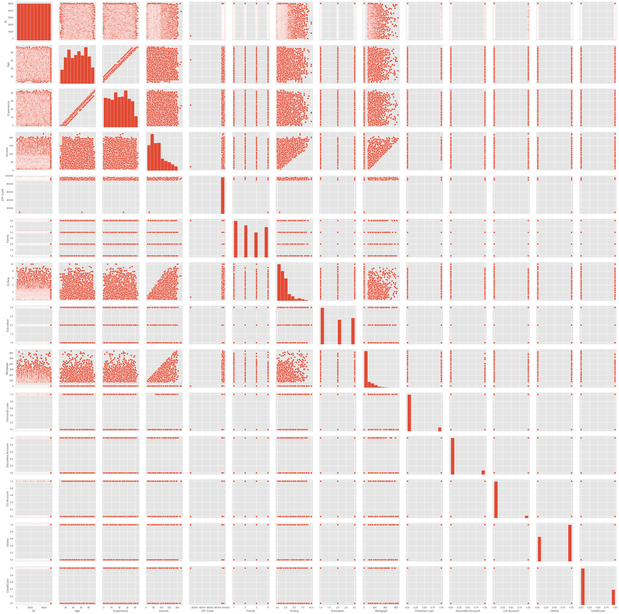

```python
#Univariate and Bivariate Analysis
sns.pairplot(df)
#1) We can see that experience and age are strongly correlated
#There are no strong relation other than the above
```

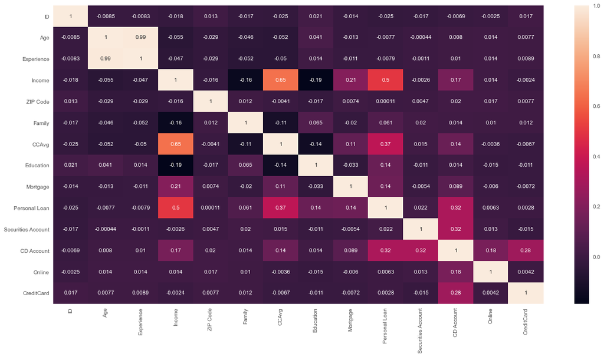

```python
sns.heatmap(df.corr(),annot=True)
#1)Age and Exp are strongly correlated
#2)Personal Loan which is a Target Variable doesnt have stong relation with any variable.It has weak relation with Income which is 0.5
#3)Income is also somewhat corelated to CreditCard Spending(0.65)
```

[output not shown]

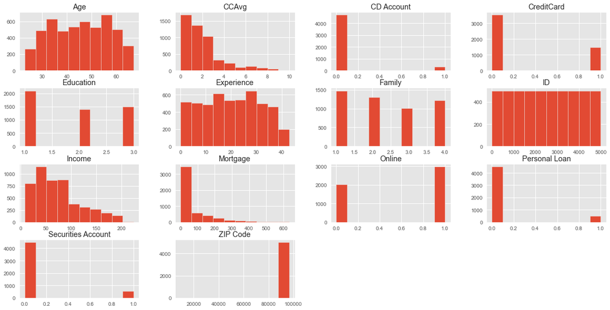

```python
#Checking distribution of individual field
hist=df.hist()
hist
```

```python
#Checking relation with Age and Personal Loan
agebins = np.arange(0, 100, 5)
agelabels =np.arange(5, 100, 5)
df['binnedAge'] = pd.cut(df['Age'], agebins,labels=agelabels)
```

```python
df.head()
```

|  | ID | Age | Experience | Income | ZIP Code | Family | CCAvg | Education | Mortgage | Personal Loan | Securities Account | CD Account | Online | CreditCard | binnedAge |
| --- | --- | --- | --- | --- | --- | --- | --- | --- | --- | --- | --- | --- | --- | --- | --- |
| 0 | 1 | 25 | 1 | 49 | 91107 | 4 | 1.60 | 1 | 0 | 0 | 1 | 0 | 0 | 0 | 25 |
| 1 | 2 | 45 | 19 | 34 | 90089 | 3 | 1.50 | 1 | 0 | 0 | 1 | 0 | 0 | 0 | 45 |
| 2 | 3 | 39 | 15 | 11 | 94720 | 1 | 1.00 | 1 | 0 | 0 | 0 | 0 | 0 | 0 | 40 |
| 3 | 4 | 35 | 9 | 100 | 94112 | 1 | 2.70 | 2 | 0 | 0 | 0 | 0 | 0 | 0 | 35 |
| 4 | 5 | 35 | 8 | 45 | 91330 | 4 | 1.00 | 2 | 0 | 0 | 0 | 0 | 0 | 1 | 35 |

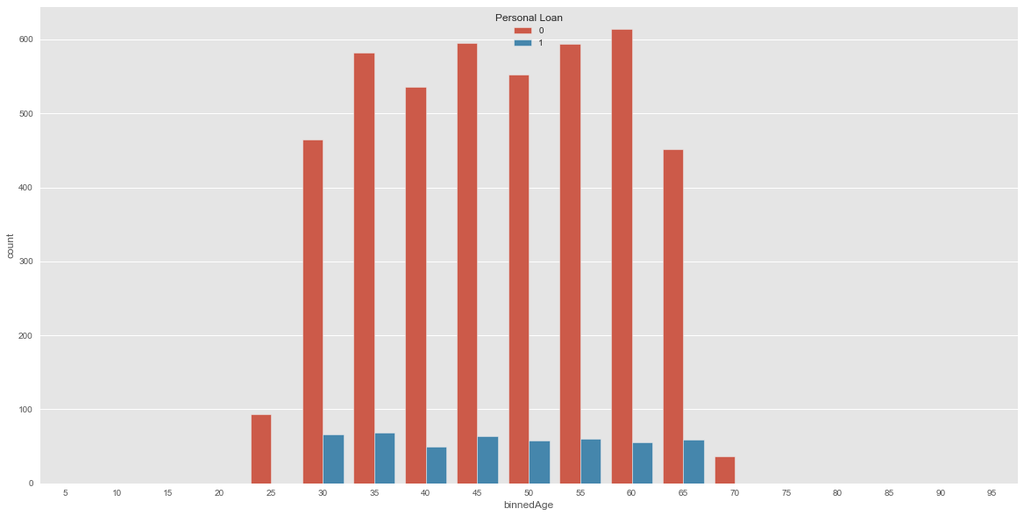

```python
#People who aquired loan are in the range 30-70
sns.countplot(x=df['binnedAge'],hue=df['Personal Loan'])
```

```python
df[df['Personal Loan']==1]
```

|  | ID | Age | Experience | Income | ZIP Code | Family | CCAvg | Education | Mortgage | Personal Loan | Securities Account | CD Account | Online | CreditCard | binnedAge |
| --- | --- | --- | --- | --- | --- | --- | --- | --- | --- | --- | --- | --- | --- | --- | --- |
| 9 | 10 | 34 | 9 | 180 | 93023 | 1 | 8.90 | 3 | 0 | 1 | 0 | 0 | 0 | 0 | 35 |
| 16 | 17 | 38 | 14 | 130 | 95010 | 4 | 4.70 | 3 | 134 | 1 | 0 | 0 | 0 | 0 | 40 |
| 18 | 19 | 46 | 21 | 193 | 91604 | 2 | 8.10 | 3 | 0 | 1 | 0 | 0 | 0 | 0 | 50 |
| 29 | 30 | 38 | 13 | 119 | 94104 | 1 | 3.30 | 2 | 0 | 1 | 0 | 1 | 1 | 1 | 40 |
| 38 | 39 | 42 | 18 | 141 | 94114 | 3 | 5.00 | 3 | 0 | 1 | 1 | 1 | 1 | 0 | 45 |
| ... | ... | ... | ... | ... | ... | ... | ... | ... | ... | ... | ... | ... | ... | ... | ... |
| 4883 | 4884 | 38 | 13 | 129 | 92646 | 3 | 4.10 | 3 | 0 | 1 | 0 | 1 | 1 | 1 | 40 |
| 4927 | 4928 | 43 | 19 | 121 | 94720 | 1 | 0.70 | 2 | 0 | 1 | 0 | 1 | 1 | 1 | 45 |
| 4941 | 4942 | 28 | 4 | 112 | 90049 | 2 | 1.60 | 2 | 0 | 1 | 0 | 0 | 1 | 0 | 30 |
| 4962 | 4963 | 46 | 20 | 122 | 90065 | 3 | 3.00 | 3 | 0 | 1 | 0 | 1 | 1 | 1 | 50 |
| 4980 | 4981 | 29 | 5 | 135 | 95762 | 3 | 5.30 | 1 | 0 | 1 | 0 | 1 | 1 | 1 | 30 |

480 rows × 15 columns

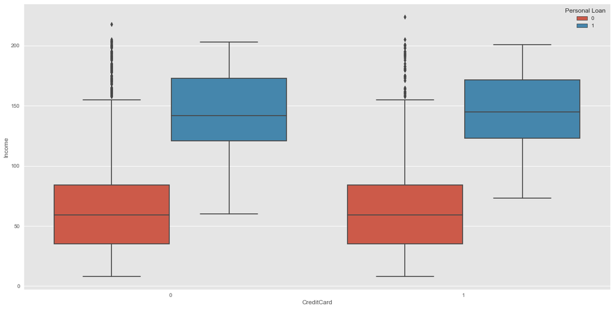

```python
sns.boxplot(x=df['CreditCard'],y=df['Income'],hue=df['Personal Loan'])
```

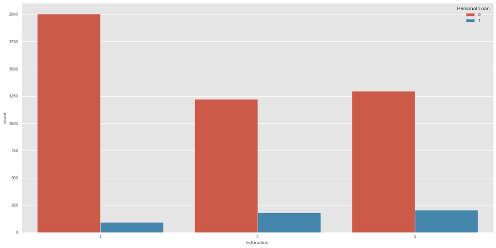

```python
#People with Education 3 (Advanced/Professional) and Education 2(Graduate) are more likely to take personal loan
sns.countplot(df['Education'],hue=df['Personal Loan'])
```

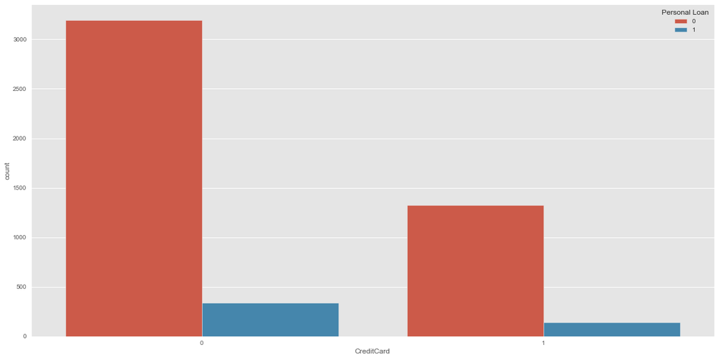

```python
#From the below it shows that people with no credit are more who accepted the personal loan
sns.countplot(df['CreditCard'],hue=df['Personal Loan'])
```